# Lecture 8 - Introduction to Lyapunov Stability Theory

Published

February 5, 2026

Based on notes created by Sam Coogan and Murat Arcak. Licensed under a “Creative Commons Attribution-NonCommercial-ShareAlike 4.0 International License”

Additional Reading

- Khalil, Chapter 4.5
- Sastry, Chapter 5

Overview

- Define Lyapunov stability notions
- Lyapunov stability theorems

# Lyanpunov Stability Theory

Consider a time-invariant dynamical system
$$\dot{x} = f(x), \quad f(0) = 0$$

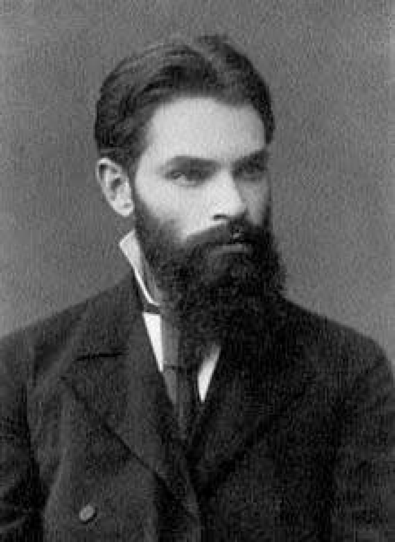

Lyapunov (1857–1918)

If the equilibrium of interest is $x^* \neq 0$, we can always shift the system through the transformation $\tilde{x} = x - x^*$, yielding:

$$\dot{\tilde{x}} = f(\tilde{x} + x^*) \triangleq \tilde{f}(\tilde{x}) \quad \implies \quad \tilde{f}(0) = 0$$

The equilibrium $x = 0$ is *stable* if for each $\epsilon > 0$, there exists a $\delta > 0$ such that

$$\underbrace{\|x(0)\| < \delta}_{\textrm{If you start within some }\delta} \implies \underbrace{\|x(t)\| < \epsilon}_{\textrm{You stay within }\epsilon}, \quad \forall t \geq 0$$

It is *unstable* if it is not stable.

It is *asymptotically stable* if stable and $x(t) \to 0$ for all x(0) in a neighborhood of $x = 0$.

It is *globally asymptotically stable* if stable and $x(t) \to 0$ for all $x(0) \in \mathbb{R}^n$.

[figure not shown]

Note: $x(t) \to 0$ does not necessarily imply stability. One can construct an example where trajectories converge to the origin but only after a large detour that violates the stability definition.

[figure not shown]

This example is a *homoclinic orbit*. The equilibrium at the origin is unstable, even though all trajectories starting at the origin converge to the origin.

1. Let $D$ be an open, connected subset of $\mathbb{R}^n$ containing the origin. If there exists a $C^1$ function $V: D \to \mathbb{R}$ such that

$$V(0) = 0, \quad \textrm{ and } V(x) > 0 \quad \forall x \in D \setminus \{0\}
\textrm{ (positive definite)}$$

and

$$\dot{V}(x) := \Delta V(x)^T f(x) \leq 0 \quad \forall x \in D \textrm{ (negative semi-definite)}$$

then $x = 0$ is stable.

2. If $\dot{V}(x) < 0$ for all $x \in D \setminus \{0\}$ (negative definite), then $x = 0$ is asymptotically stable.
3. If, in addition, $D = \mathbb{R}^n$ and
   $$V(x) \to \infty \textrm{ as } \|x\| \to \infty \textrm{ (radially unbounded)}$$
   then $x = 0$ is globally asymptotically stable.

*Proof*. (Sketch) The sets $\Omega_C \triangleq \{ x \mid V(x) \leq C \}$ for constraints $c$ are called *level sets* of $V$ and are positively invariant because $\Delta V(x)^T f(x) \leq 0$.

Stability: choose a level set inside the ball of radius $\epsilon$ and a ball of radius $\delta$ inside this level set. Trajectories starting in $\mathcal{B}_{\delta}$ cannot leave $\mathcal{B}_{\epsilon}$ since they remain inside the level set.

[figure not shown]

Asymptotic Stability: since $V(x(t))$ is decreasing and bounded below by $0$, we conclude

$$V(x(t)) \to c \geq 0$$

We will show $c = 0$ (i.e., $x(t) \to 0$) by contradiction. Suppose $c \neq 0$. This would mean that level set is bounded above and below:

[figure not shown]

Let

$$\gamma \triangleq \min_{\{x: ~c \leq V(x) \leq V(x_0)\}} ~-\dot{V}(x) > 0$$

<sup>1</sup> By positive definiteness of $V$, the level sets $\{x\mid V(x) \leq \textrm{constant}\}$ are bounded when the constant is sufficiently small. Since we are proving *local* asymptotic stability we can assume $x_0$ is close enough to the origin that the small constant $V(x_0)$ is sufficiently small.

$$\dot{V}(x) \leq -\gamma \quad \implies V(x(t)) \leq V(x_0) - \gamma t$$

which implies $V(x(t)) < 0$ for $t > \frac{V(x_0)}{\gamma}$, a contradiction because $V \geq 0$. Therefore, $c=0$ which implies $x(t) \to 0$.

Global Asymptotic Stability: Why do we need radial unboundedness?

Example:

$$V(x) = \frac{x_1^2}{1+x_1^2} + x_2^2$$

Since $x_2 = 0$, let $x_1 \to \infty$: $V(x) \to 1$ (not radially unbounded). Then, $\Omega_c$ is not a bounded set for $c \geq 1$. Therefore, $x_1(t)$ may grow unbounded while $V(x(t))$ is decreasing.

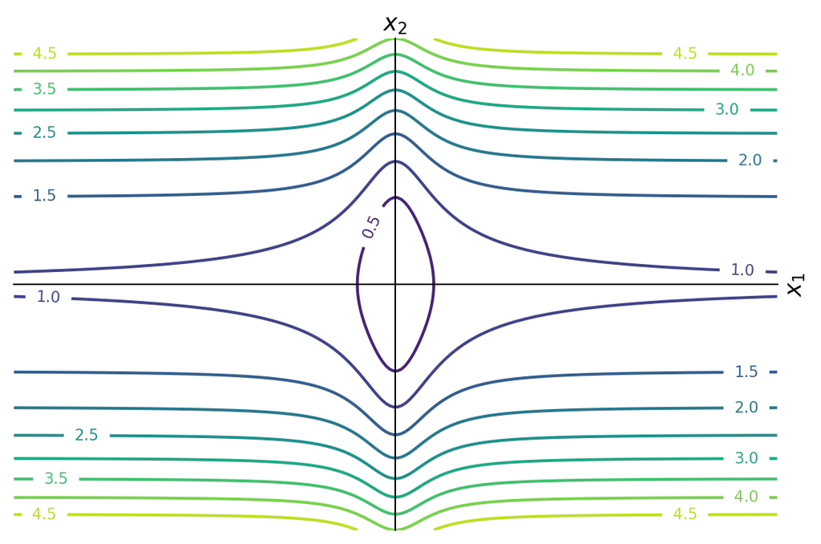

Level sets for $V(x) = \frac{x_1^2}{1+x_1^2} + x_2^2$ (not radially unbounded)

```python
import numpy as np
import matplotlib.pyplot as plt

# Create a grid
x1 = np.linspace(-10, 10, 200)
x2 = np.linspace(-2, 2, 200)
X1, X2 = np.meshgrid(x1, x2)

# Lyapunov function: V(x) = x1^2/(1+x1^2) + x2^2
V = X1**2 / (1 + X1**2) + X2**2

# Create contour plot
fig, ax = plt.subplots(figsize=(6, 4))
contour = ax.contour(X1, X2, V, levels=10, cmap='viridis')
ax.clabel(contour, inline=True, fontsize=8)

ax.spines['left'].set_position('zero')
ax.spines['bottom'].set_position('zero')
ax.set_xlabel(r'$x_2$', fontsize=12)
ax.set_ylabel(r'$x_1$', fontsize=12)
ax.xaxis.set_label_position('top')
ax.yaxis.set_label_position('right')
ax.spines['right'].set_visible(False)
ax.spines['top'].set_visible(False)
plt.xticks([])
plt.yticks([])
plt.tight_layout()
plt.show()
```

## Finding Lyapunov Functions

**Example**: Consider the general nonlinear system

$$\dot{x} = -g(x), \quad x \in \mathbb{R}, ~xg(x) > 0 ~\forall x \neq 0$$

$V(x) = \frac{1}{2}x^2$ is positive definite and radially unbounded.

$\dot{V}(x) = x \dot{x} = -x g(x) < 0$ (negative definite). Therefore, $x=0$ is globally asymptotically stable.

If $xg(x) > 0$ only in some domain $(-b,c) \setminus \{0\}$, then we can only conclude local asymptotic stability of $x=0$ on the domain $D = (-b,c)$.

If there are other equilibria where $g(x) = 0$ then we can also only conclude local asymptotic stability of $x=0$.

**Example**: Consider the nonlinear system[^2]
$$\begin{align*}
\dot{x}_1 &= x_2 \\
\dot{x}_2 &= -a x_2 - g(x_1), \quad a \geq 0, xg(x) > 0 ~\forall x \in (-b,c) \setminus \{0\}
\end{align*}$$

<sup>2</sup> The pendulum is a special case of this system with $g(x) = \sin(x)$, which has equilibrium points at $x=0$ and $x = \pm \pi$. Therefore, we know that global stability will not be possible for this system and we will need to restrict our domain to $D = (-\pi, \pi)$.

The choice $V(x) = \frac{1}{2}x_1^2 + \frac{1}{2}x_2^2$ doesn’t work because $\dot{V}(x)$ is sign indefinite (you can try this for yourself).

Instead we will consider the function

$$V(x) = \int_0^{x_1} g(y) dy + \frac{1}{2} x_2^2.$$

This function is positive definite on $D=(-b,c) \setminus \{0\}$. Checking it’s derivative:

$$\begin{align*}
\dot{V}(x) &= \frac{\partial V}{\partial x} f(x) \\
&= \begin{bmatrix}\frac{\partial V}{\partial x_1} & \frac{\partial V}{\partial x_2} \end{bmatrix} f(x) \\
&= \begin{bmatrix} g(x_1) & x_2 \end{bmatrix} \begin{bmatrix} x_2 \\ -a x_2 - g(x_1) \end{bmatrix} \\
&= g(x_1) x_2 + x_2 (-a x_2 - g(x_1)) \\
&= -a x_2^2 \leq 0
\end{align*}$$

Therefore, we can conclude stability of our equilibrium within $D$.

If $a = 0$, we will not be able to conclude asymptotic stability since
$$\dot{V}(x) = 0 \implies V(x(t)) = V(x_0)$$

If $a > 0$, we actually will be able to conclude asymptotic stability but we will need to use the LaSalle-Krasovskii Invariance Principle which is covered in the next lecture. This is because we cannot yet conclude that $\dot{V}(x) < 0 ~\forall x \in D \setminus \{0\}$.